# Hotel Booking Analysis

Ana Mohapatra, Charlie Logan, Jonathan Demeter, Nikita Mehendale, Srishti Senthil

February 21, 2021

## Table of Contents

### 1. Introduction

### 2. Arrivals

#### iii. Peak, Normal, and Slow Weeks

#### iv. Regression Model for Arrivals Frequency

### 3. Pricing

### 4. Companies and Agents

#### i. Companies’ Mean Price Per Stay

#### ii. Companies’ Number Of Bookings

#### iii. Agents’ Mean Price Per Stay

#### iv. Agents’ Number of Bookings

### 5. Cancellations

#### i. Cancellation Rate for each Hotel

#### ii. Cancellations by Nationality

#### iii. Cancellations by Month

#### iv. Cancellations by Market Segment

#### v. Cancellations by Duration of Stay

#### vi. Cancellations by Deposit Type

#### vii. Cancellations by Group Composition

#### viii. Cancellations by Previous Instance of Cancellations

#### iix.Cancellations by Lead Time

### 6. Conclusion

## Introduction

The hotel bookings dataset available via Kaggle contains nearly 120,000 unique hotel bookings over the course of three years at two businesses, City Hotel and Resort Hotel. In this report we will generate a series of insights related to guest arrivals, room pricing, organizational booking, and guest cancellation such that these hotels can improve their decision making when it comes to these areas.

## Arrivals

Each reservation entry contains information about the day, month, week, and year of the guest’s arrival. In this section we will take a look at trends of the busiest and quietest times of the year.

### Arrivals by Month

In the barplot pictured below, we generate a frequency distribution to display the proportion of total bookings per month based on arrival date.

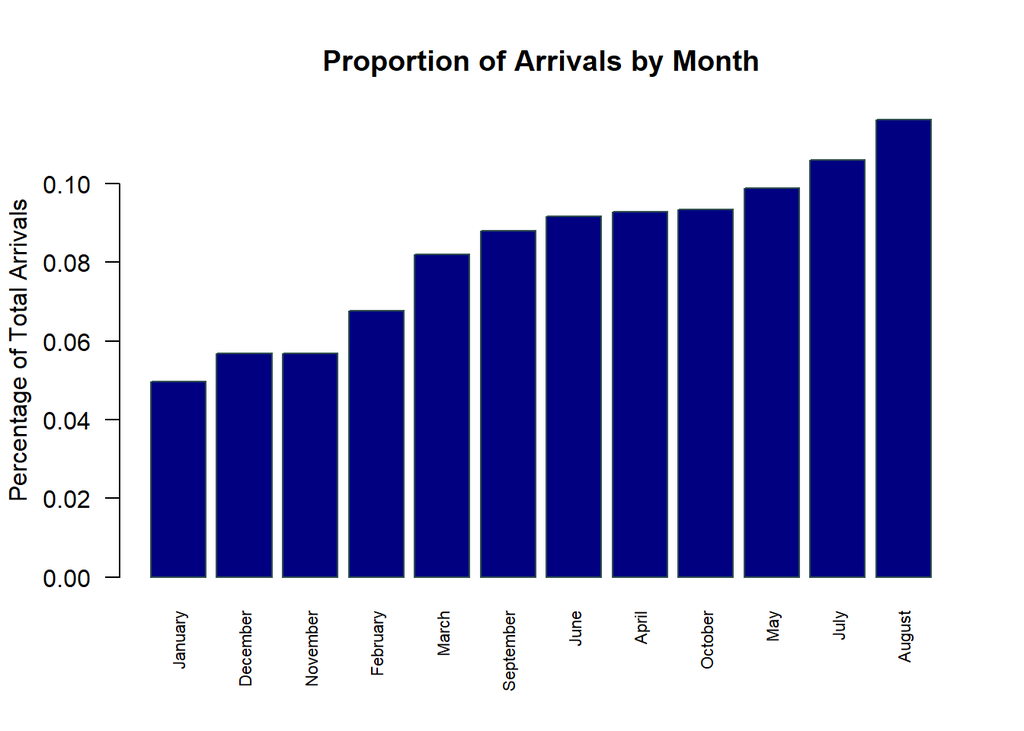

From the above plot, it is clear that guests book the greatest number of stays arriving during the peak summer months of July and August. Guests book the fewest number of stays to arrive during the winter months of January and December. Hotels may consider events or promotions to promote bookings during these slower months. Hotels could also lower their prices or cut down on operational costs during those months to maximize profit.

### Arrivals by Week

We can break up our examination of arrival time to a more granular level, looking at guest arrival by week number, with week 1 being the first week of January and week 52 being the last week of December. This will allow us to gain more insight into the busiest times of the year beyond busy months.

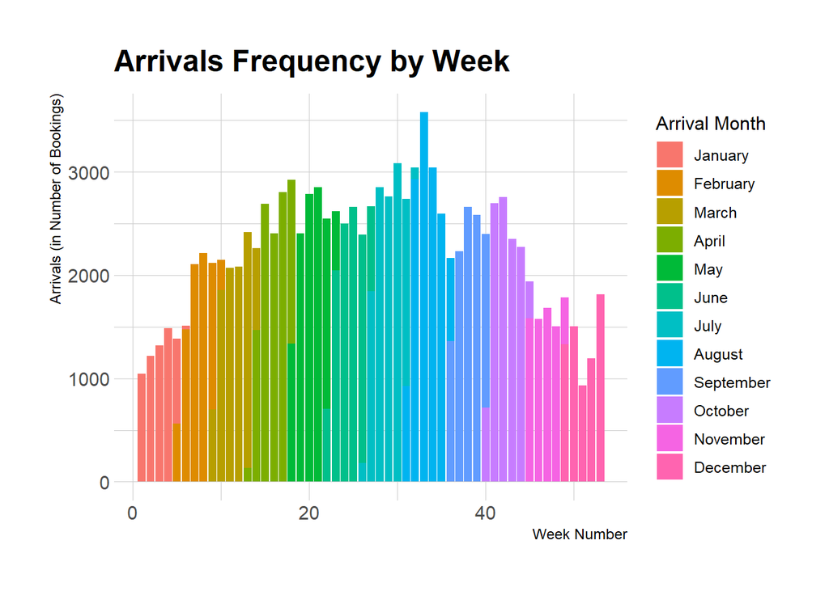

This barchart combines the data we have already seen to follow arrivals frequency over time. The arrivals by week gives a closer look at popular weeks for people to book reservations. The hotel may investigate these patterns to prepare for high and low seasons accordingly. This could include purchasing supplies according to expected volume, adjusting staffing on a given week, and setting prices according to demand.

### Peak, Normal, and Slow Weeks

We can also categorize different times of the year based on how busy they are. We chose to add “Peak”, “Normal”, and “Slow” labels to a new column in the weekly_arrivals data based on the frequency of arrivals in that week number.

```
##    Min. 1st Qu.  Median    Mean 3rd Qu.    Max.
##     933    1816    2391    2253    2689    3580
```

```
## Normal   Peak   Slow
##     25     21      7
```

We have now grouped the by-week arrivals data into “season” labels, with 21 weeks of the year considered to be peak season, 25 weeks more typical without extreme swells in guest numbers, and 7 weeks which are significantly below typical guest intakes.

### Regression Model for Arrivals Frequency

By generating a linear regression model based on season, we can gain further insight into what each season represents.

```
##
## Call:
## lm(formula = Frequency.of.Arrivals ~ season, data = weekly_arrivals)
##
## Residuals:
##     Min      1Q  Median      3Q     Max
## -570.08 -146.24   -2.24  189.92  772.76
##
## Coefficients:
##             Estimate Std. Error t value Pr(>|t|)
## (Intercept)  2074.08      55.11  37.633  < 2e-16 ***
## seasonPeak    733.16      81.57   8.988 5.13e-12 ***
## seasonSlow   -847.51     117.84  -7.192 3.00e-09 ***
## ---
## Signif. codes:  0 '***' 0.001 '**' 0.01 '*' 0.05 '.' 0.1 ' ' 1
##
## Residual standard error: 275.6 on 50 degrees of freedom
## Multiple R-squared:  0.7939, Adjusted R-squared:  0.7857
## F-statistic:  96.3 on 2 and 50 DF,  p-value: < 2.2e-16
```

We can interpret the above regression model as follows: Frequency of arrivals is explained by season per the linear function: Frequency.of.Arrivals = 2074 + 733*(peak_season,1,0) - 847.5(slow_season,1,0)

If the week changes from a normal season to a peak season, the hotels can estimate an aggregate 733 additional arrivals that week. If the week changes from a normal season to a slow season, the hotels can estimate an aggregate 848 fewer arrivals that week. This may be useful for quick decision-making in purchasing or event management by hotel management. The adjusted r-squared value indicates that season explains 78.6% of the variance in frequency of arrivals, which is reasonably significant.

Arrivals is an interesting distribution which he have now visualized in several different plots and models. We will seek to compare this data to price information in the following section.

## Pricing

By digging into the pricing tendencies, we can help the hotels better understand where they are properly meeting guest demand during high seasons and where they are not.

The average daily rate across all reservations in both hotels is as follows:

```
##   City Hotel Resort Hotel
##    105.30447     94.95293
```

This table shows us that on average, customers pay more per day at City Hotel rather than Resort Hotel.

Now let’s look at how different factors effect the total price that customers have to pay for their stay. Does the distribution channel have an effect on how much a customer pays?

```
## Corporate Undefined       GDS     TA/TO    Direct
##  166.8554  234.2000  238.3286  368.8172  373.2401
```

It appears corporate distribution channel pays the least while the direct distribution channel leads to the highest price.

Does paying a deposit have an effect on how much a customer pays?

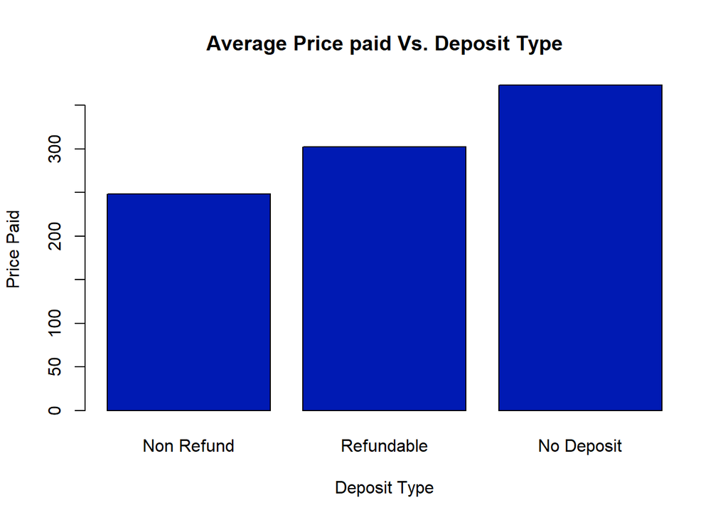

We can see that the highest price is charged when there is no deposit and the lowest price is paid when the deposit was Non Refundable.

We can visualize the changes in pricing by plotting vertical boxplots of the average daily rate against week number. The dots on the top and bottom at each weekly interval represent prices significantly above or below the median, while the lines inside the box represent the 1st quartile, median, and 3rd quartile of prices in a given week.

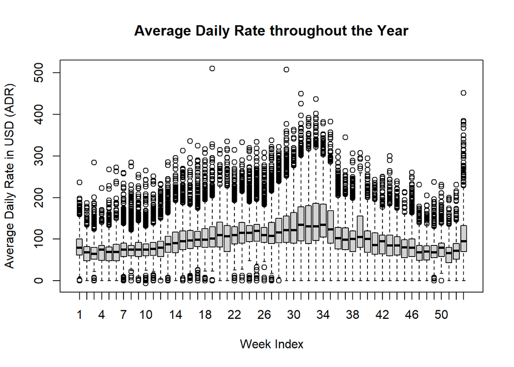

Already, the points appear to be higher in mid-year (peak summer) and at year-end (around Christmas through New Year’s). It is clear that the thick middle lines (denoting the median) hike upward to higher ADR around Weeks 30-34 and surely for Week 53, confirming our hypothesis. In general, all boxplots are skewed slightly right, since each week, a few bookings were significantly higher-priced than the critical mass.

Now the ADR data is ready to be compared with weekly arrivals.

```
## [1] 1
```

```
##    Min. 1st Qu.  Median    Mean 3rd Qu.    Max.    NA's
##   64.40   75.12  100.40   97.02  113.73  145.84       1
```

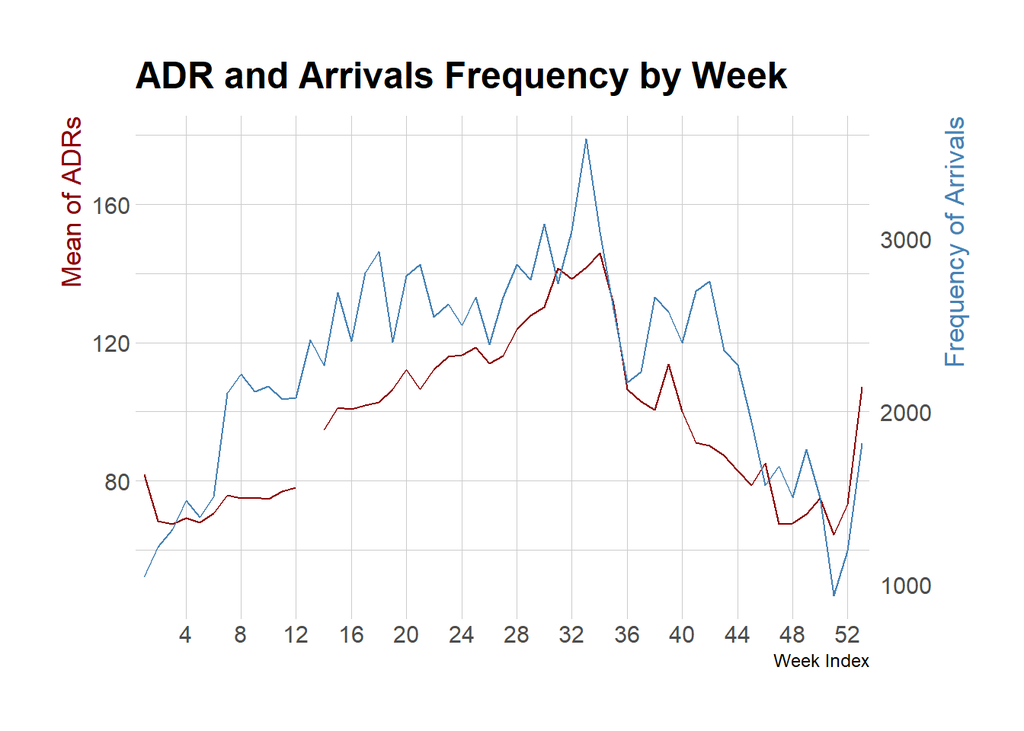

The double line chart demonstrates a high correlation between ADR and arrivals frequency through the course of a year. Rates are hiked during busier weeks, and rates are lowered during slower weeks. The hotels are able to capitalize on an opportunity to maximize revenue during these high-demand weeks.

To make some quantitative statements regarding the relationship between these two response variables, we can compare ADR across peak, normal, and slow weeks (in terms of arrivals frequency) with a table as follows:

```
## # A tibble: 3 x 3
##   season count_of_wks mean_adr
## * <fct>         <int>    <dbl>
## 1 Normal           25     87.1
## 2 Peak             21    117.
## 3 Slow              7     70.3
```

On average across both hotels, $87 is charged nightly during normal season, $117 is charged nightly during peak season, and $70 is charged nightly during the slow season.

## Companies and Agents

If we take a look at the companies that book at hotels for corporate travel or events and the agents that book rooms for guests, the hotels can better understand which corporate and agent relationships are most beneficial to them and potentially target more advertising or offer certain discounts accordingly.

### Companies’ Mean Price Per Stay

Which companies have the highest mean price per stay for City Hotel?

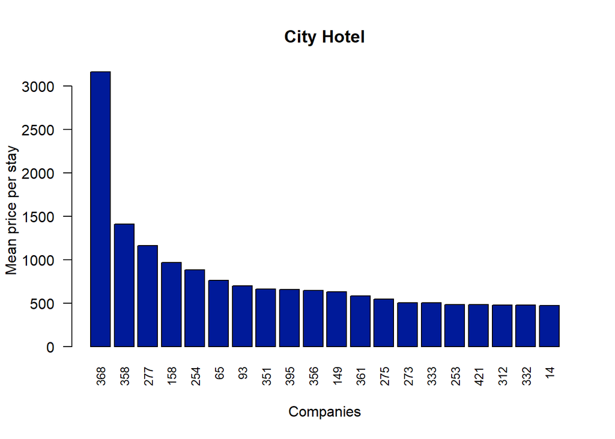

From the above graph, City Hotel can identify which companies have the highest mean price per stay. For example, City Hotel can see that Company 368 generates the most reveue per stay. It is about twice the revenue generated per stay of the Company 358, which is the second highest.

Which companies have the highest mean price per stay for Resort Hotel?

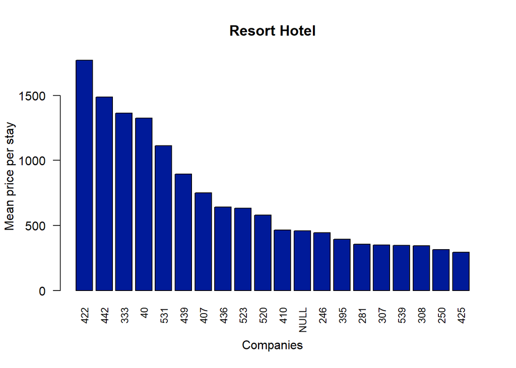

From the above graph, Resort Hotel can identify which companies have the highest mean price per stay. For example, Resort Hotel can see that Company 422 generates the most reveue per stay.

### Companies’ Number Of Bookings

Which companies have the highest number of bookings for City Hotel?

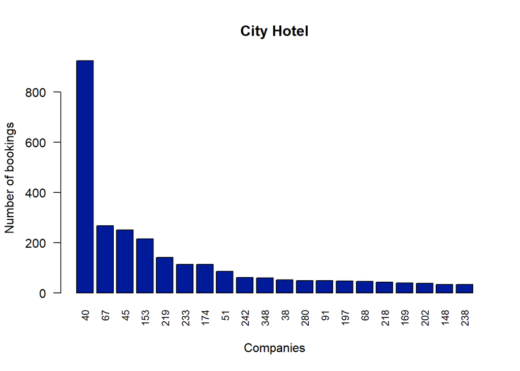

City Hotel can use this to identify which companies have the highest number of bookings. For example, City Hotel can see that Company 40 has the highest number of bookings at the hotel. It is approximately 4 times as much as the second highest company’s (Company 67’s) number of bookings.

Which companies have the highest number of bookings for Resort Hotel?

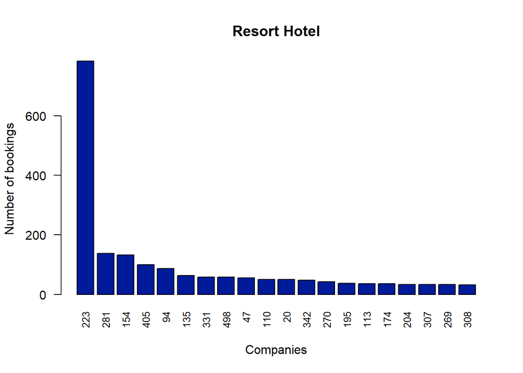

Similarly, Resort Hotel can use this identify which companies have the highest number that Company 223 has the highest number of bookings at the hotel, which is much higher than the second most number of bookings.

Using the above data, City and Resort hotel can decide which companies to deepen their ties with based on the mean revenue and number of bookings they get from each company. For example, City Hotel can choose to provide discounts to the top 10 companies in terms of bookings in order to encourage loyalty (and more bookings) from that company.

### Agents’ Mean Price Per Stay

Which agents have the highest mean price per stay for City Hotel?

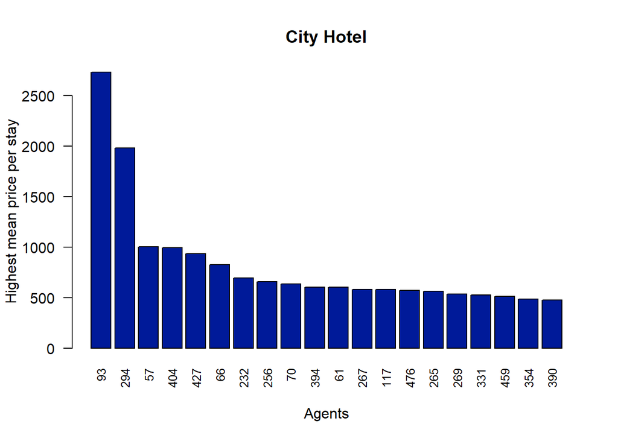

Agent 93 generates the most reveue per stay on average for City Hotel by a fairly significant margin. This agent is clearly a very valuable asset for the hotel and they should be sure to do whatever they can to maintain that relationship to keep the business coming through them.

Which agents have the highest mean price per stay for Resort Hotel?

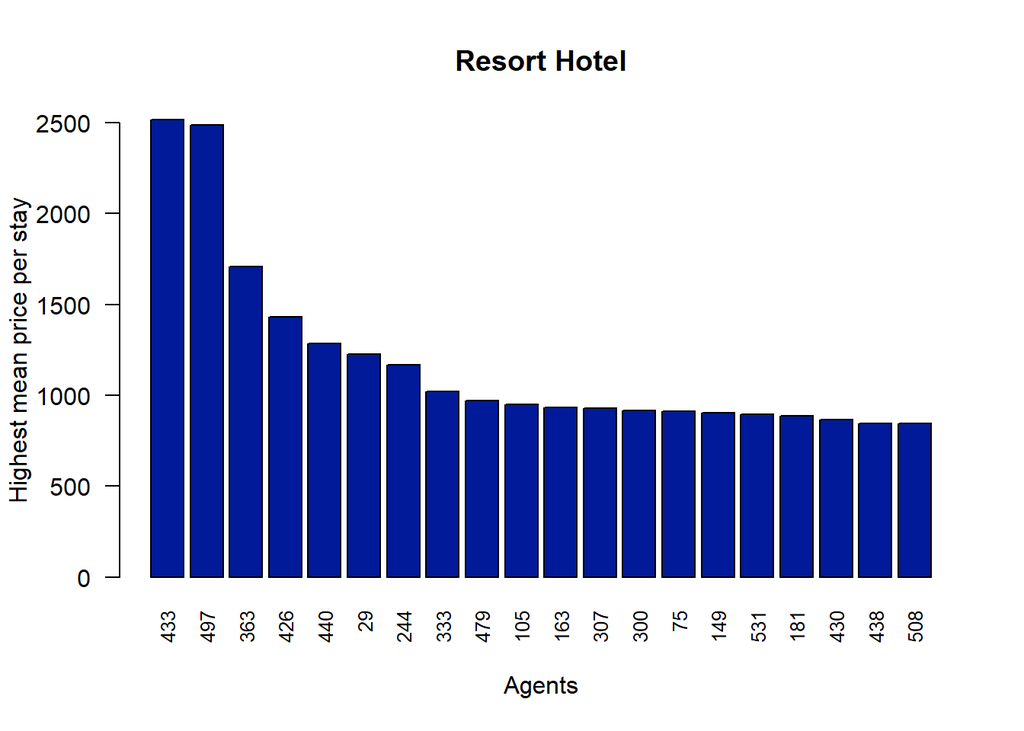

For resort hotel, Agent 433 generates the most revenue per stay. Agent 497, the second highest agent also has a similar mean price per stay. These two agents, selling similarly high prices per stay, are valuable assets for the hotel.

### Agents’ Number of Bookings

Which agents have the highest number of bookings for City Hotel?

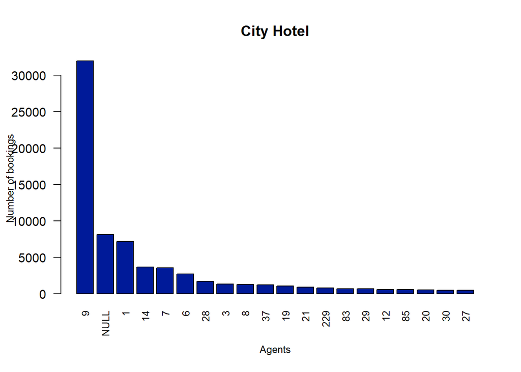

From the above graph, City Hotel can identify which agents have the highest number of bookings. For example, City Hotel can see that Agent 9 has the highest number of bookings at the hotel. It is more than 3 times as much as the second highest agent, Agent 1.

Which agents have the highest number of bookings for Resort Hotel?

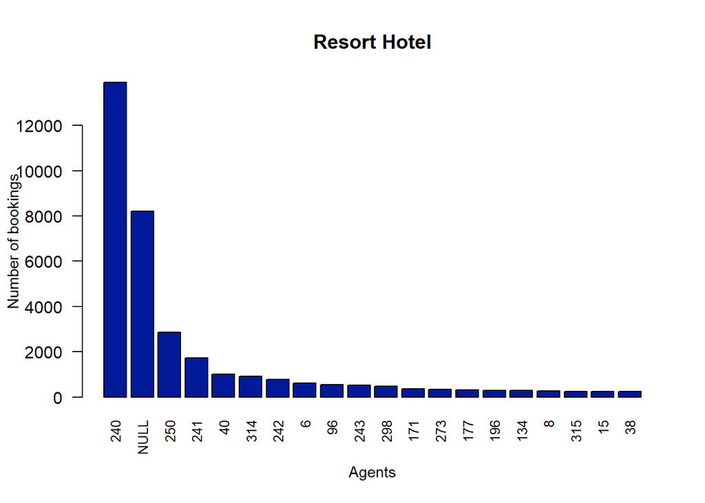

From the above graph, Resort Hotel can identify which agents have the highest number of bookings. For example, Resort Hotel can see that Agent 240 has the highest number of bookings at the hotel. It is approximately 5 times as much as the second highest agent, Agent 250.

Using the above data, the City and Resort hotel can decide which agents to deepen their ties with based on the mean revenue and number of bookings they get from each agent. For example, Resort Hotel can choose to provide discounts to the top 5 agents in terms of bookings in order to encourage loyalty from those agents.

## Cancellations

### Cancellation Rate for each Hotel

Of the two hotels in our dataset, City Hotel and Resort Hotel, which has a higher average cancellation rate?

```
##   City Hotel Resort Hotel
##        41.73        27.76
```

City hotel has a higher cancellation rate, about 42% of reservations are canceled, while only about 28% of bookings are cancelled at Resort Hotel. This is a valuable base statistic to know how many people that booked a reservation will actually end up staying at each hotel. This is valuable because if each hotel knows about how many people will be staying during a given period they can plan their supplies accordingly to maximize profit.

### Cancellations by Nationality

We can compare the count and rate of cancellations by people from each country on the following graphs

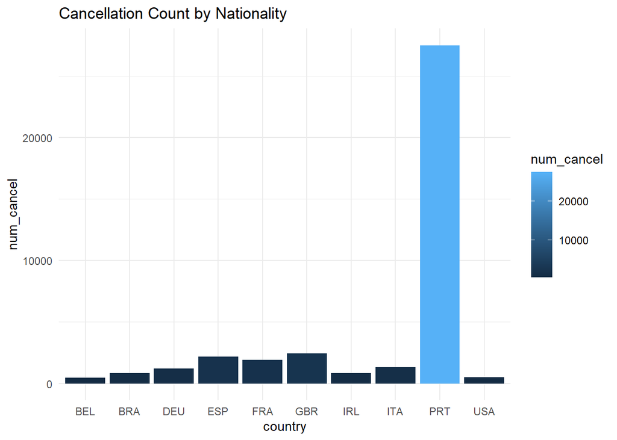

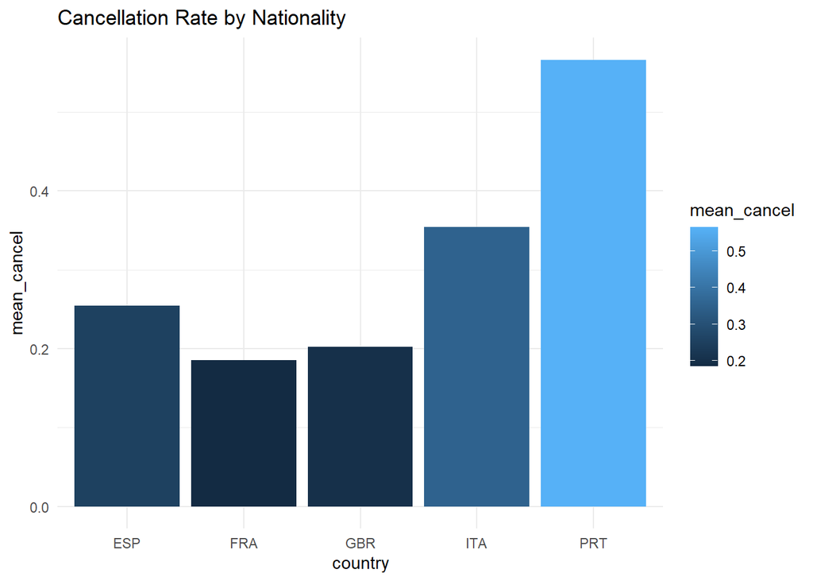

People from Portugal have the highest cancellation count by far. The two hotels are probably located in Portugal and therefore most reservations are made by Portugese people. This explains the high cancellation count. Looking at the cancellation rate for the 5 nationalities with highest cancellation count shows that people from Portugal cancel their bookings at a much higher rate than those from Italy, Great Britain, France, and Spain. This makes intuitive sense because people traveling from further distances are less liekly to cancel than people from Portugal who are traveling domestically.

### Cancellations by Month

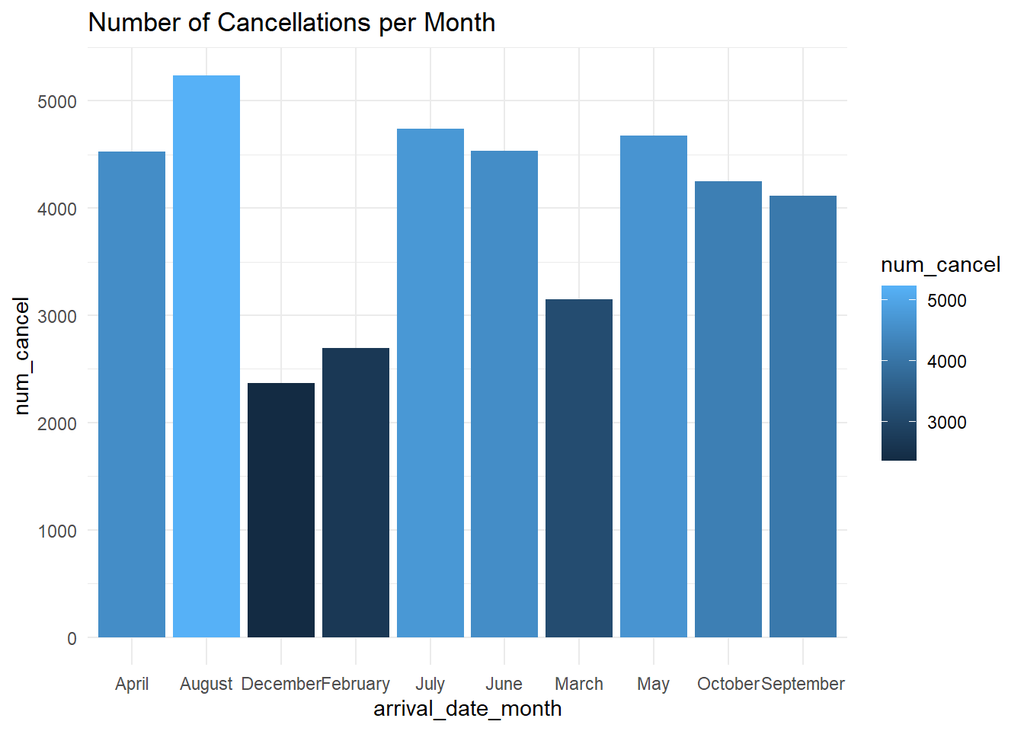

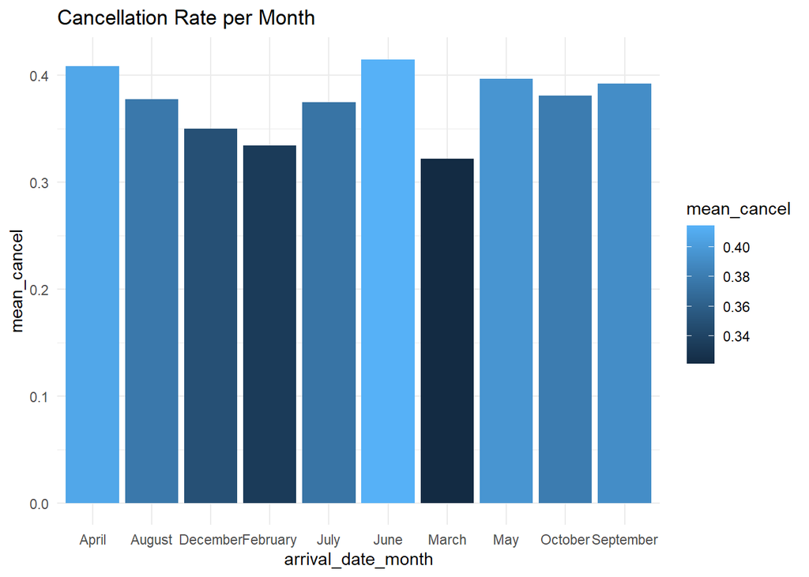

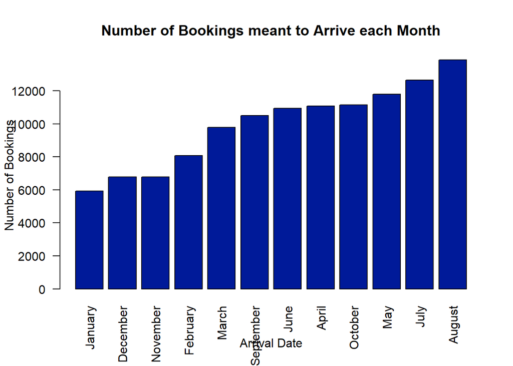

We can see that August and July have the most amount of cancellations based on the graphs above. But the months of June and April have the highest rates of cancellation. This difference can be explained because August and July have the most amount of reservations, so it would make sense they also have a high cancellation count. This data can be combined with bookings per month to be used in trying to estimate actual volume of people in the hotels each month. This is valuable for figuring out the quanitity of resources and staff the hotels need each month.

### Cancellations by Market Segment

The market segment with the highest cancellation count is the online travel agency market segment. The highest cancellation rate however is the Groups segment (besides the Undefined segment because there are only two instances of that which isn’t substantial enough to make conclusions on)

```
## # A tibble: 8 x 2
##   market_segment num_cancel
##   <chr>               <int>
## 1 Online TA           20739
## 2 Groups              12097
## 3 Offline TA/TO        8311
## 4 Direct               1934
## 5 Corporate             992
## 6 Complementary          97
## 7 Aviation               52
## 8 Undefined               2
```

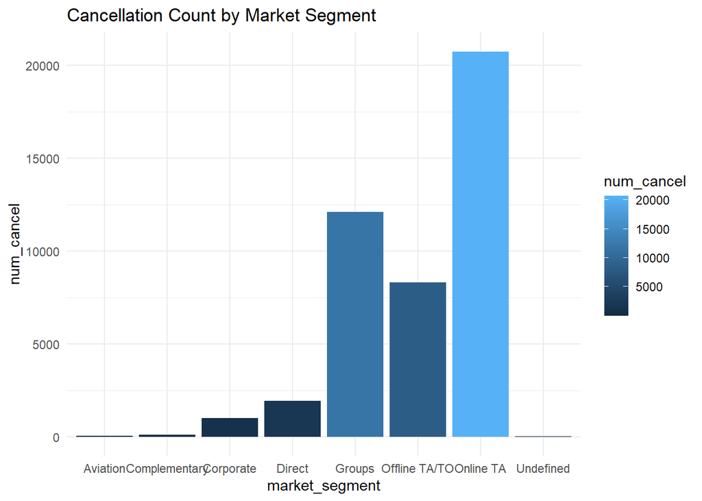

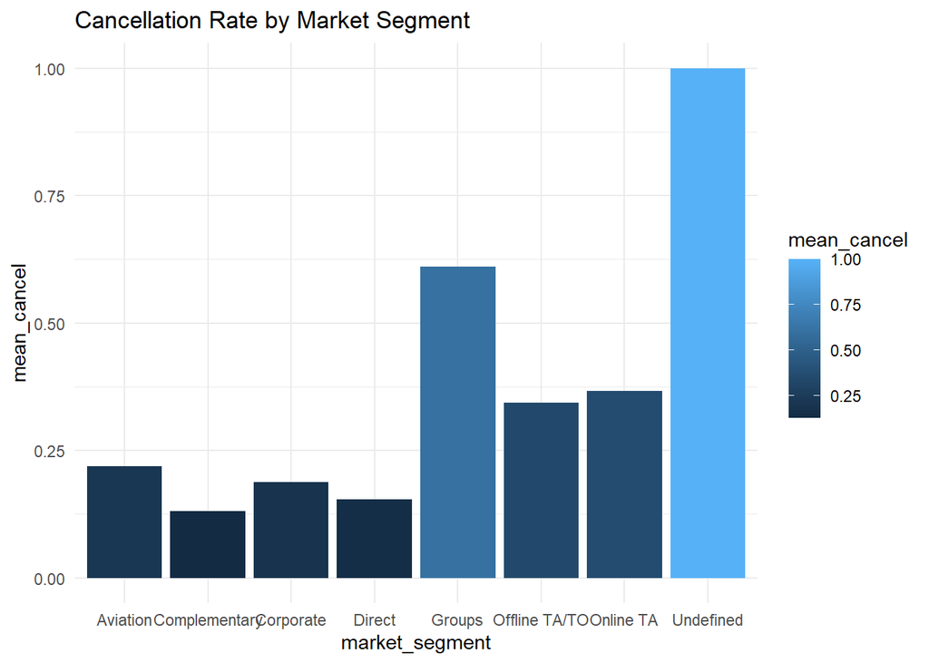

```
## # A tibble: 8 x 2
## # Groups:   market_segment [8]
##   market_segment     n
##   <chr>          <int>
## 1 Aviation         237
## 2 Complementary    743
## 3 Corporate       5295
## 4 Direct         12606
## 5 Groups         19811
## 6 Offline TA/TO  24219
## 7 Online TA      56477
## 8 Undefined          2
```

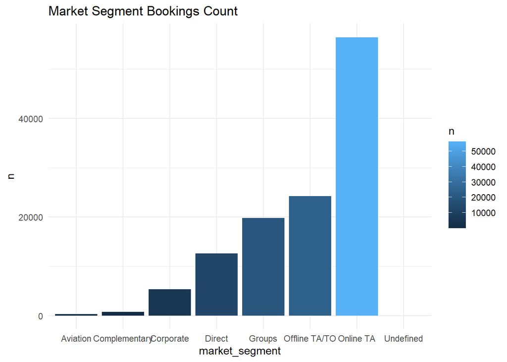

People book their hotel reservations primarily by online travel agencies and in result it has the highest cancellation count. This can be valuable to the hotels because they can either target customers further through travel agencies, or try to market on the lesser market segments such as the corporate sector.Interestingly, the groups segment has the highest cancellation rate. Maybe the hotels can market less toward this segment as they aren’t reliable in showing up.

### Cancellations by Duration of Stay

Is staying a fewer numbers of days more likely to be canceled then staying a week? First we explore how cancellation is affected by duration of stay.

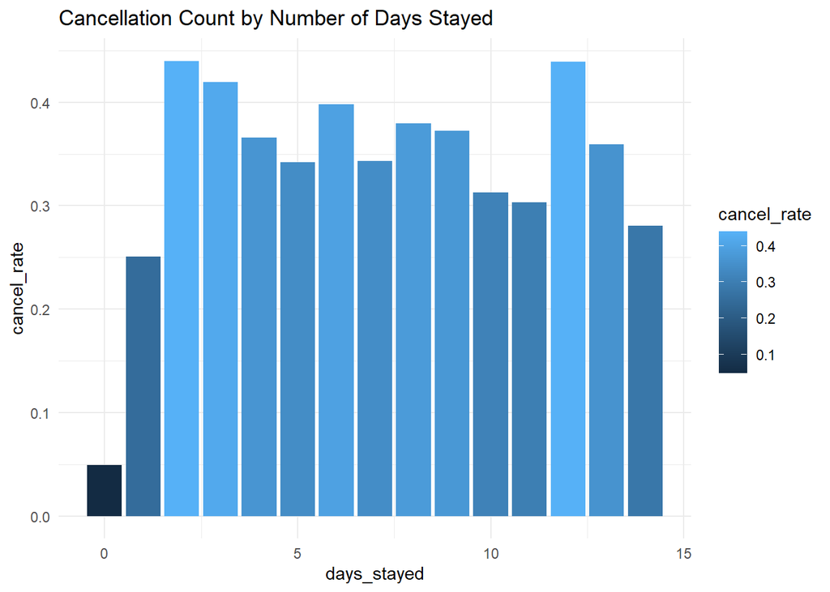

```
## # A tibble: 2 x 2
##   week_stay cancel_rate
## *     <dbl>       <dbl>
## 1         0       0.373
## 2         1       0.348
```

By looking at the first graph it isnt so clear whether a longer stay is less likely to be canceled because of the high cancellation for 12 day bookings. When we break up the data into 7 days stays or not, we can see there is a slightly higher probability of a stay less than a week being cancelled.

Are guests staying only during the week more likely to cancel than guest staying only during the weekend?

```
## # A tibble: 2 x 2
##   weekDayOnly Cancel_rate
## *       <dbl>       <dbl>
## 1           0       0.271
## 2           1       0.380
```

### Cancellations by Deposit Type

Do deposits make it less likely for someone to cancel?

```
## # A tibble: 3 x 2
##   deposit_type num_cancel
## * <chr>             <int>
## 1 No Deposit        29694
## 2 Non Refund        14494
## 3 Refundable           36
```

```
## # A tibble: 3 x 2
## # Groups:   deposit_type [3]
##   deposit_type      n
##   <chr>         <int>
## 1 No Deposit   104641
## 2 Non Refund    14587
## 3 Refundable      162
```

```
## # A tibble: 3 x 2
##   deposit_type cancel_rate
## * <chr>              <dbl>
## 1 No Deposit         0.284
## 2 Non Refund         0.994
## 3 Refundable         0.222
```

Strangely, 99% of Non Refundable deposits ended up being canceled. This seems counter intuitive and a ridiculously high cancellation rate regardless of the context, especially because the count of Non Refundable deposits is ~14k which is very high. This leads me to believe this data is corrupted or the Non Refund deposit type is only determined if a cancellation is happening. Regardless, the Non Refund deposit type doesn’t seem informative. Bookings with no deposit cancel at a higher rate than refundable deposits however, a rate of 28.4% Vs. 22.2%.

### Cancellations by Group Composition

Are groups booking with children more or less likely to cancel their reservation? The table below indicates that groups with children and without children cancel reservations at about the same rate, at about 37% for parties without children and about 34% for those with children.

```
##   has_children is_canceled
## 1        FALSE   0.3721900
## 2         TRUE   0.3492285
```

Traveling with children indicates a group is slightly less likely to cancel their reservation, but does that pattern change if the guest is traveling with a baby and no older children? The table below shows the difference in cancellation rates between parties with more than one baby and parties with either no babies or other children.

```
##   has_baby is_canceled
## 1    FALSE   0.3716118
## 2     TRUE   0.1792453
```

Those with one or more babies in their party but no children are much less likely to cancel a reservation, at a cancellation rate of about 17% as compared to a party with just adults or adults and children canceling at a rate of about 37%. Young families with babies seem to be more reliable in their bookings, which is valuable information for a hotel to have when planning availabity and projecting which reservations are going to fall through.

In addition to information about who is in a given party, hotels save information about guests previous cancellation behavior. Is a guest that has cancelled a reservation in the past more likely to cancel again? The table velow indicates that a guest who canceled a reservation previously is highly likely to cancel again, showing a cancellation rate of about 91% for prior cancellers and a below average rate of about 34% for guests who have no record of previous cancellation.

### Cancellations by Previous Instance of Cancellations

```
##   has_previous_cancellation is_canceled
## 1                     FALSE   0.3390608
## 2                      TRUE   0.9164096
```

The barplot pictured below shows the cancellation rate of these two groups. If hotels are concerned about cancellations and would like to improve their ability to predict which guests will not end up staying at the hotel, ensuring guests who have canceled in the past do not repeat would be a good place to start.

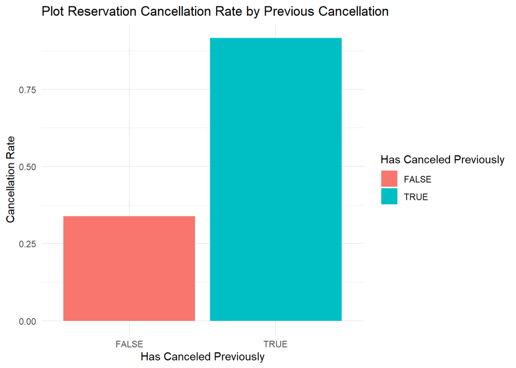

We have seen that there is a stark difference in cancellation rates for guests with and without a previous cancellation on file, but is there any noticeable difference between the two hotels with regards to repeat cancellations?

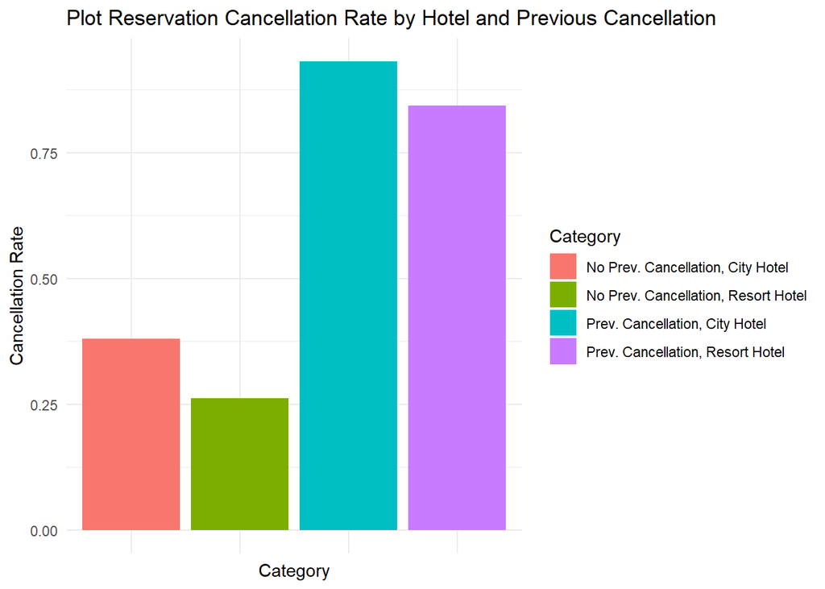

We can see that just as it is higher overall, City Hotel’s cancellation rate is higher than that of Resort Hotel regardless of whether or not the guest had previously canceled a reservation. Guests with track records of cancellation has no significant difference between the hotels, both should be aware of the high likelihood of those guests canceling again.

### Cancellations by Lead Time

Another potential tool a hotel could use to anticipate whether a guest will follow through with their reservation is how far in advance the reservation was booked. If we break up every reservation into bins of less than a week in advance, between 1 week and 1 month, 1 and 2 months, 2 and 4 months, 4 and 6 months, 6 to 8 months, and 8+ months in advance, we get bins with at least 10,000 reservations in each category to look into which has the highest cancellation rate.

The table below indicates that the more lead time with which a reservation was booked, the more likely the party is to cancel it.

```
##       lead_bin is_canceled
## 1      <7 days  0.09394515
## 2    7-30 days  0.26548492
## 3   30-60 days  0.36340371
## 4  60-120 days  0.41679238
## 5 120-180 days  0.44886470
## 6 180-240 days  0.45676077
## 7    240+ days  0.64417838
```

The graph below shows the cancellation rate at each time interval of booking.

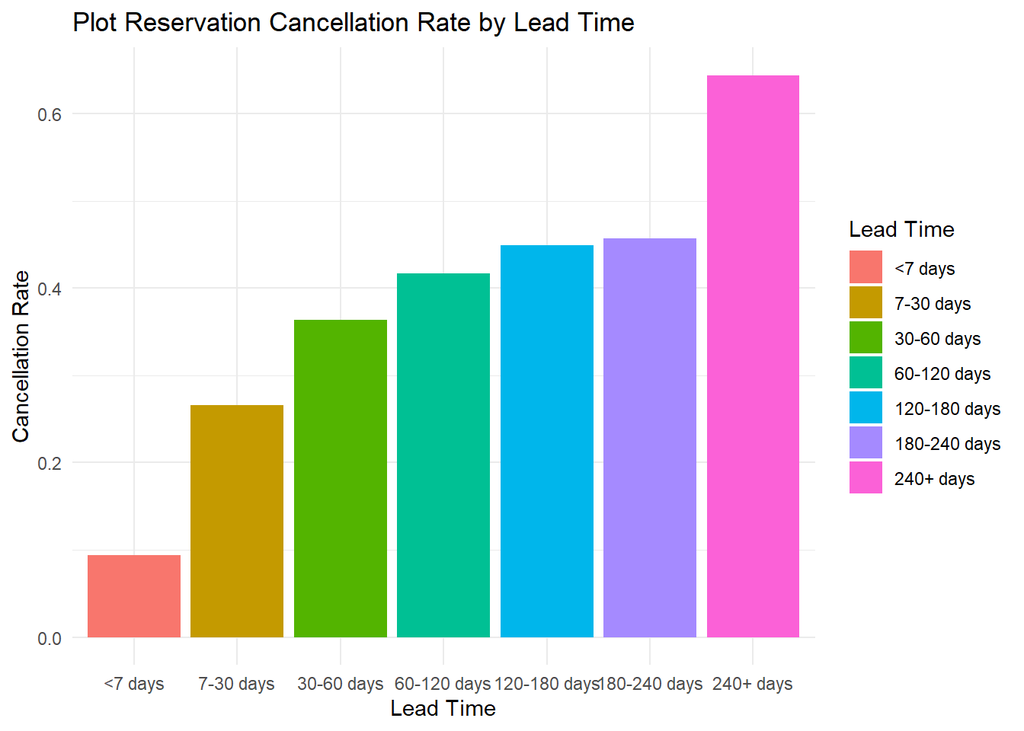

The cancellation rate crosses the mean cancellation threshold of 37% for the first time in the 60-120 days range, or between 2 and 4 months before the hotel stay date. It continues to grow from there, where the cancellation rate for a reservation more than 8 months out is around 64%, more than double the rate of reservations booked within a month. This trend is likely due to the fact that guests will make plans far in advance knowing that things may change between booking and the actual stay. If there isn’t a penalty for cancellation or there is an insignificant one, guests will continue to book far in advance even if they do not fully intend to follow through on the reservation.

# Conclusion

The report analyzed pricing, cancellation, customer arrivals, company, and agent data to provide useful conclusions. Based on the insights in the arrivals section, the hotels can better prepare for busy seasons and ensure materials aren’t wasted during quiet seasons. Using the data from the pricing section, they can assess how they are meeting demand by adjusting prices and evaluate whether a systematic change is needed in the setting of prices. By reading the companies and agents section, the hotels can better understand their relationship with third-parties in order to get the most out of those partnerships. Finally, using the insights generated in the cancellation section, the hotels can make more informed decisions around guest bookings to limit cancellations, which can be harmful to the hotel business model.